# Formula E in numbers

[figure not shown]

The following data visualizations reflect information contained in the “Formula E Results” dataset from FIA Formula E, an electric-car auto racing championship. Data pertains to race results from 2014-2016, as well as pilot, circuit, and race characteristics. The set includes nineteen (19) columns and 2,509 rows of information. The data collected is used to track racer performance, as well as to identify circuit competitiveness, trends in speed, and to yield other insights which can help to optimize team and circuit formation.  
This report contains the following visualizations: Waffle Charts, Boxplot, Dumbbell, Density Chart, Scatterplots, and Small multiples.

## Did it ever occur to you how many drivers do not finish the race?

Some drivers may not finish the race because of following reasons:

- Mechanical failure
- Car accident
- Suspension from race

1 Square = 1 Driver/Circuits

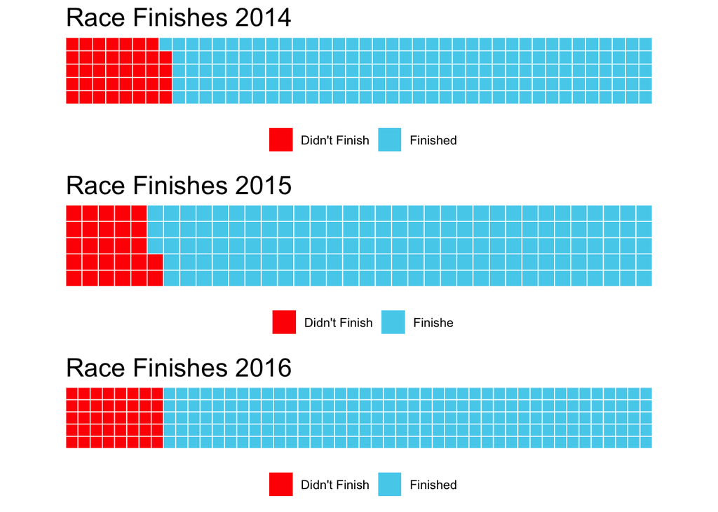

## Who have been the dominant teams and drivers over the past three years?

1 square = 1 win/Circuits

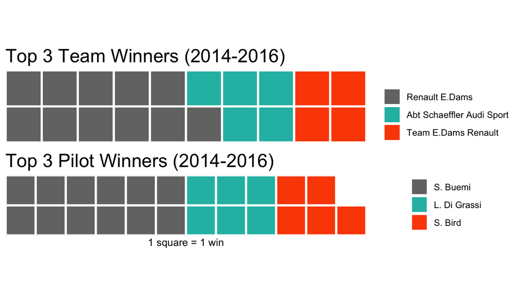

## Not all circuits are equally competitive! Which one is the least competitive?

Beijing is the least competitive circuit as it has the widest spread, which is equivalent to saying that drivers performed differently during the race. Whereas, Miami has a very narrow spread, which means that drivers were close to each other.

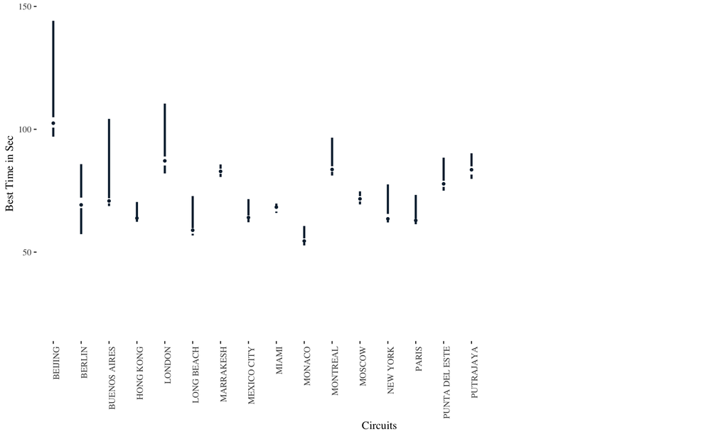

## Highst Rank vs. Lowest Rank by team

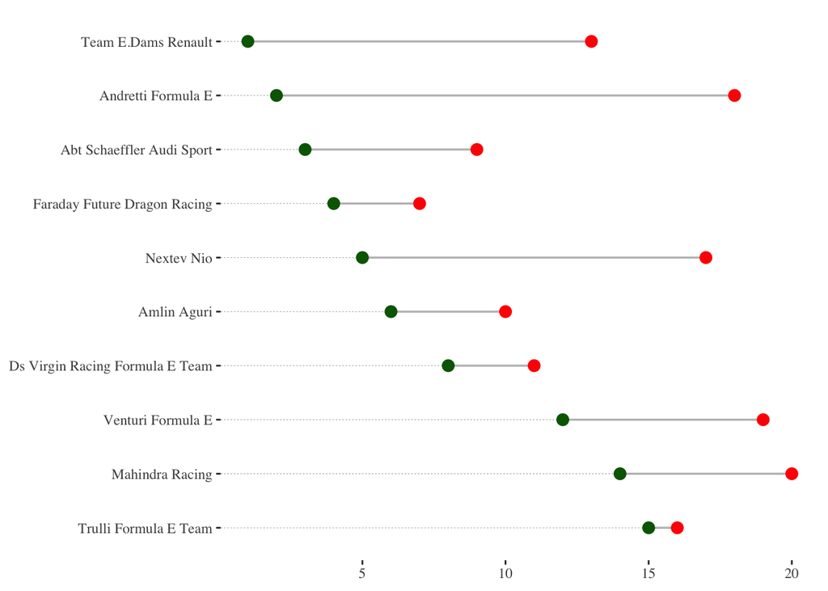

## Does the maximum speed increase in Races ?

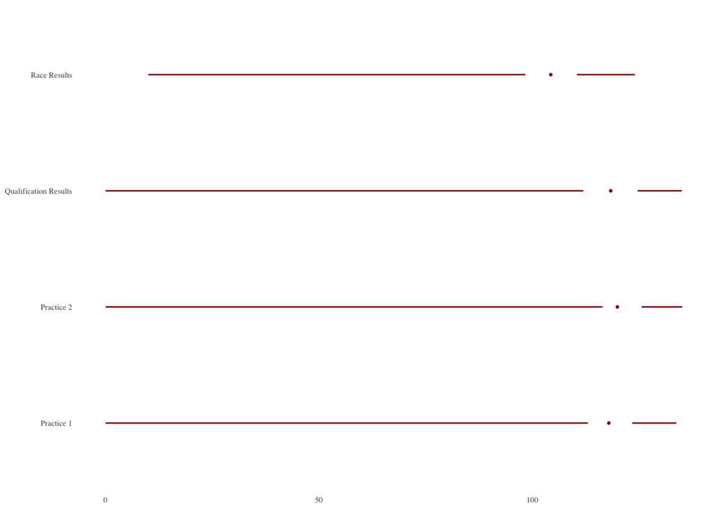

## Position in Qualifications vs. Race (by pilot)

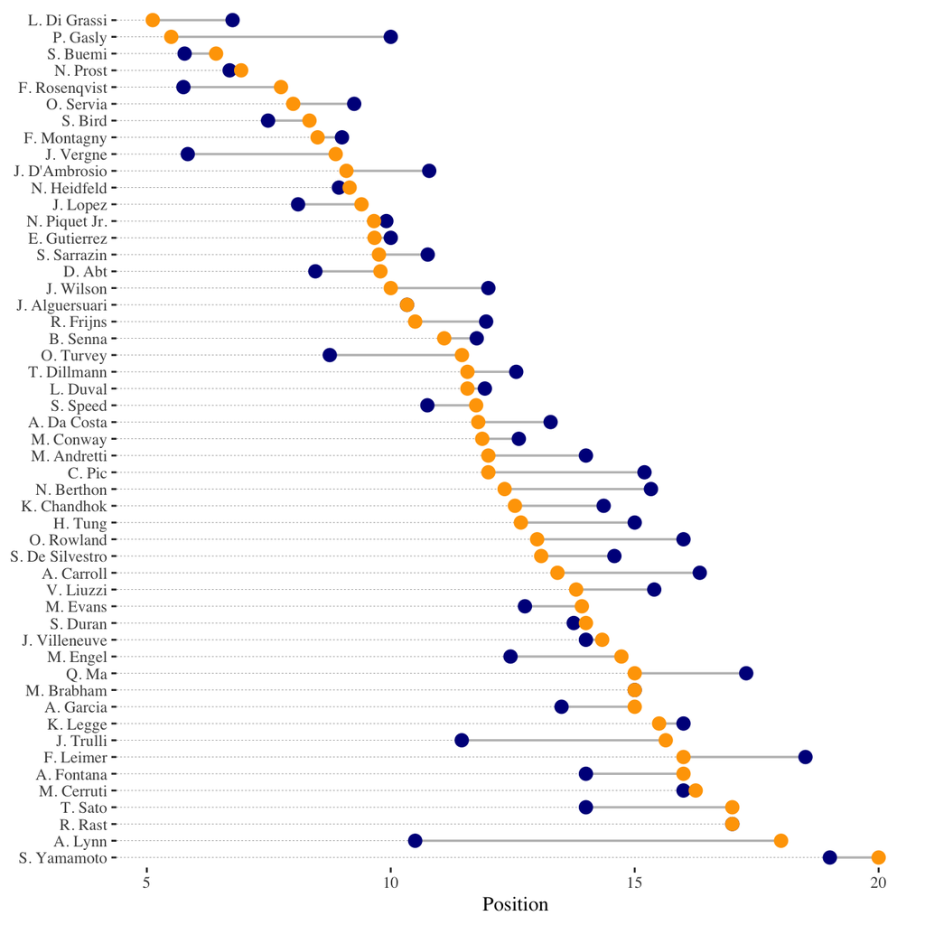

## Speed in Practice vs. Race (by pilot) Do you think drivers pace more in Race compared to practice?

Fact: Drivers are faster during practice because there are no competitors and they do not need to be concerned about low fuel and burning tires

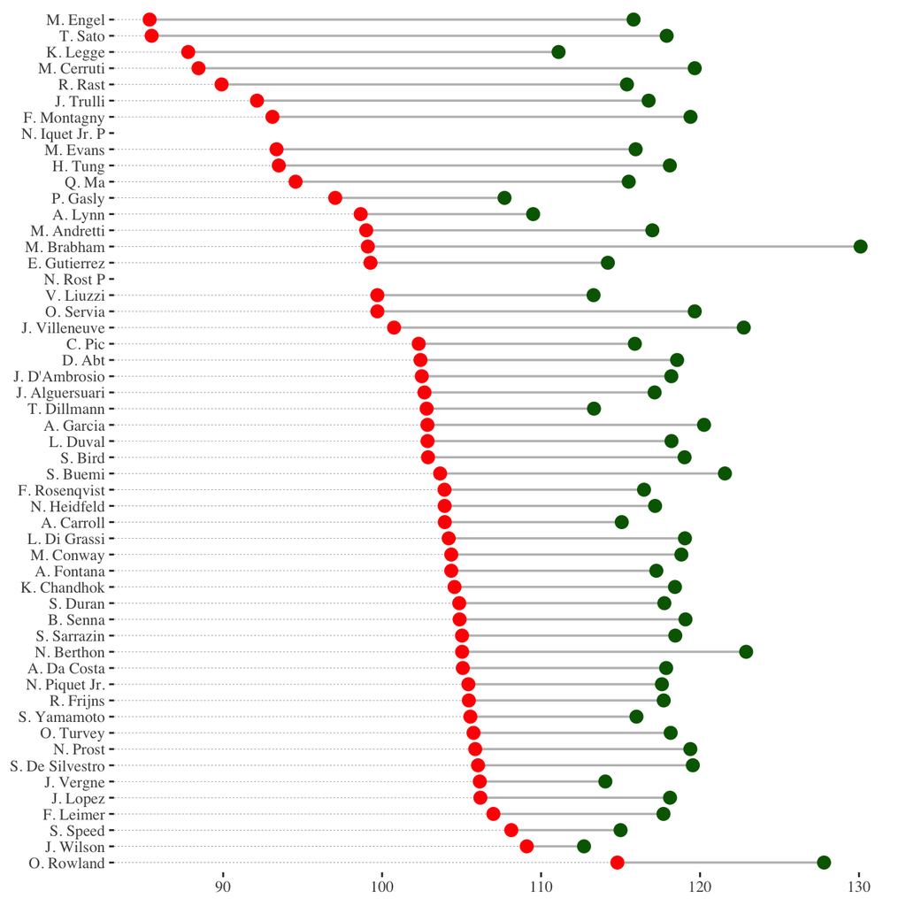

## Team participation over time

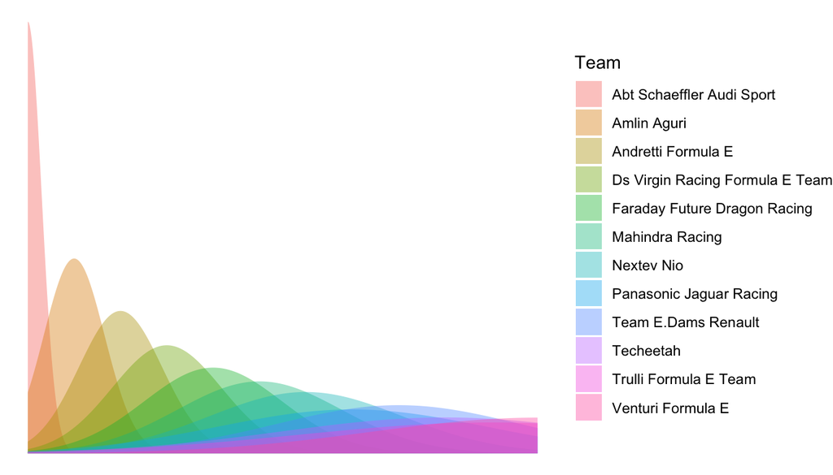

## How has each time ranked over time ?

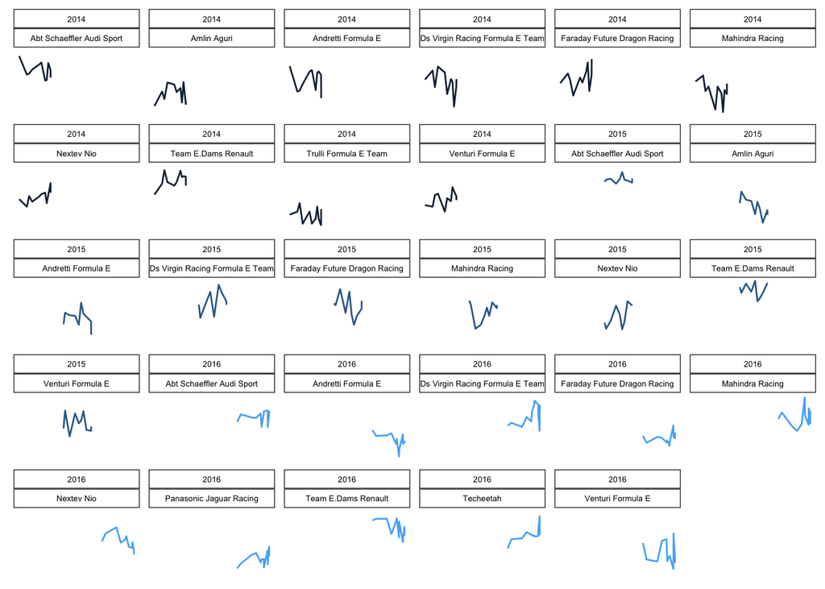

## How fast does pilots drive in different circuits ?

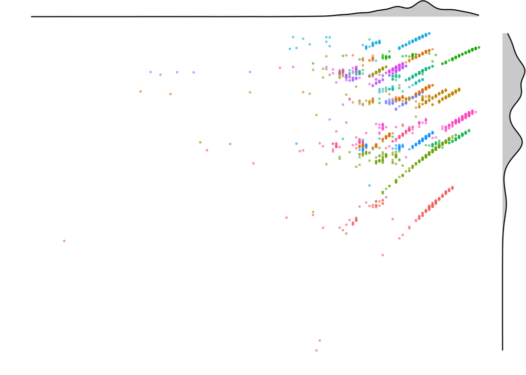

## Created by Workgroup O-1-5

## MBD-18